# Credit Approval Analysis

May 1, 2015

## Background

**Objective:**  
To demonstrate the analytical techniques taught during the Special Topics in Audit Analytics course at Rutgers University

**Data:**  
- Dataset- Credit Screening on Credit Card Applications  
- Source- UCI Machine Learning Repository

**Assumptions:**  
Field names and values changed to meaningless values. Made assumtions about what attributes the data represents.

## Research Question - 1

**Q:** Is there a relationship between Age, Income, Credit Score, and Debt levels and the credit approval status? Can this relationship be used to predict if a person is granted credit? If yes, does the relationship indicate reasonable risk management strategies?

## Research Question - 1

**Q:** Is there a relationship between Age, Income, Credit Score, and Debt levels and the credit approval status? Can this relationship be used to predict if a person is granted credit? If yes, does the relationship indicate reasonable risk management strategies?

**A:** Relationships exists between Prior default, Years employed, Credit score, and Income level. These variables are reasonable management strategies.

## Research Question - 2

**Q:** Ethnicity is a protected status and the decision to approve or deny an application cannot be based on the applicant's ethnicity. Is there a statistically significant difference in how credit is granted between ethnicities that could indicate bias or discrimination?

> H0: Ethnicity and approval are independent.  
> H1: Approval status is dependent on the ethnicity and credit card company has a compliance risk.

## Research Question - 2

**Q:** Ethnicity is a protected status and the decision to approve or deny an application cannot be based on the applicant's ethnicity. Is there a statistically significant difference in how credit is granted between ethnicities that could indicate bias or discrimination?

> H0: Ethnicity and approval are independent.  
> H1: Approval status is dependent on the ethnicity and credit card company has a compliance risk.

## Analytic Methods Used

Methods used:

## Linear Regression

Used to fill in missing values in Age

```
                Age  Debt YearsEmployed CreditScore Income
Age           1.000 0.202         0.396       0.186  0.019
Debt          0.202 1.000         0.301       0.271  0.122
YearsEmployed 0.396 0.301         1.000       0.327  0.053
CreditScore   0.186 0.271         0.327       1.000  0.063
Income        0.019 0.122         0.053       0.063  1.000
```

```
  (Intercept) YearsEmployed
    28.446953      1.412399
```

## Descriptive Stats and Normalization

Convert values to Z-Scores

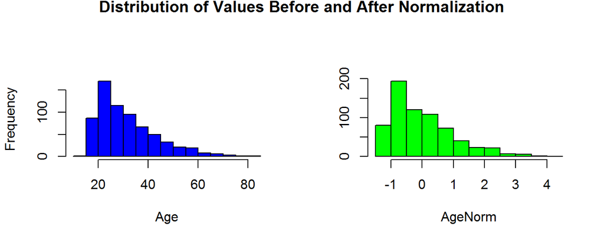

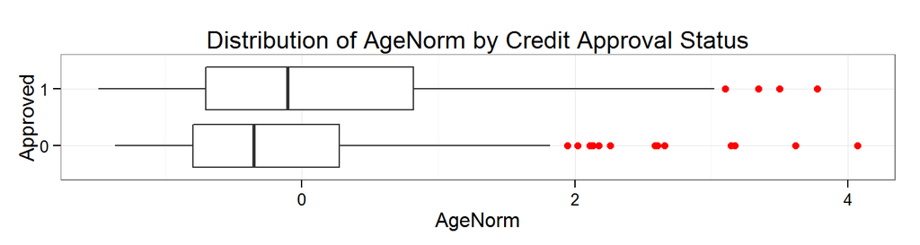

## Association Rules

```
  lhs                   rhs        support confidence     lift
1 {EducationLevel=c} => {Male=0} 0.1545319  0.7647059 1.099673
```

## Baseline Model

- Simple mean of results.
- Establish benchmark to measure model accuracy

```
  Total Success Percent
1   517     230   44.49
```

## Logistic Regression

```
Call:
glm(formula = Approved ~ AgeNorm + DebtLog + YearsEmployedLog +
    CreditScoreLog + IncomeLog, family = binomial, data = Train)

Deviance Residuals:
    Min       1Q   Median       3Q      Max
-2.4339  -0.7848  -0.4970   0.7164   2.1596

Coefficients:
                 Estimate Std. Error z value Pr(>|z|)
(Intercept)      -0.10596    0.11283  -0.939 0.347648
AgeNorm           0.01541    0.11674   0.132 0.894965
DebtLog           0.08430    0.11635   0.725 0.468744
YearsEmployedLog  0.70937    0.13021   5.448 5.10e-08 ***
CreditScoreLog    1.01687    0.13944   7.293 3.04e-13 ***
IncomeLog         0.46610    0.12089   3.855 0.000116 ***
---
Signif. codes:  0 '***' 0.001 '**' 0.01 '*' 0.05 '.' 0.1 ' ' 1

(Dispersion parameter for binomial family taken to be 1)

    Null deviance: 698.11  on 506  degrees of freedom
Residual deviance: 500.25  on 501  degrees of freedom
  (10 observations deleted due to missingness)
AIC: 512.25

Number of Fisher Scoring iterations: 5
```

```
    FALSE TRUE
  0   238   40
  1    79  150
```

## CART Model

```
n= 517

node), split, n, loss, yval, (yprob)
      * denotes terminal node

1) root 517 230 0 (0.55512573 0.44487427)
  2) PriorDefault=0 247  16 0 (0.93522267 0.06477733) *
  3) PriorDefault=1 270  56 1 (0.20740741 0.79259259) *
```

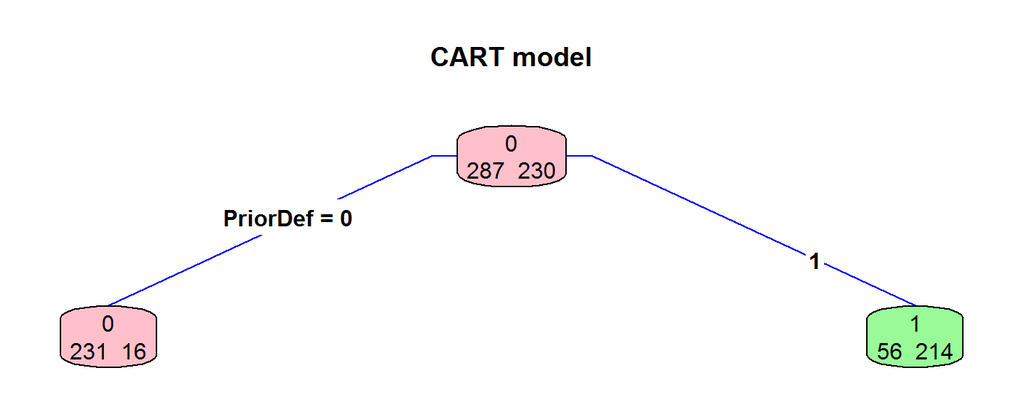

## References

Data:  
http://archive.ics.uci.edu/ml/machine-learning-databases/credit-screening

Analytic Report:  
http://www.rpubs.com/kuhnrl30/CreditScreen